# Part 1: Regression models: predicting COVID mortality risk

In Part I, we will firstly summarize the characteristics of the US county-level study cohort up to Nov. 1, 2021. Then we will be using linear regression models to predict mean COVID mortality rate (per 100,000), and logistic regression models to predict the probablity of mortality rate >= median value.

## Step 0: read in the dataset

```r
# read in dataset
library(dplyr)
```

```r
library(ggplot2)
library(plotly)
library(Matrix)
library(MASS)
library(lme4)
df <- read.csv("/Users/jenniferdai/Desktop/BST260-Final-Project/Data/aggregate_pm_census_cdc_211031.csv")
head(df)
```

```
##   fips mean_pm25 mean_winter_temp mean_summer_temp mean_winter_rm
## 1 1001 10.376526         288.0851         306.0235       85.65184
## 2 1003  9.272959         290.2089         305.5166       89.73097
## 3 1005  9.636003         289.2421         306.0622       88.63357
## 4 1007 10.726068         287.3628         305.9822       86.48587
## 5 1009 10.639869         285.5657         305.1789       85.44914
## 6 1011  9.711007         288.6913         305.8677       89.16812
##   mean_summer_rm  Admin2 Province_State Country_Region    Last_Update      Lat
## 1       96.05542 Autauga        Alabama             US 2021/11/1 4:22 32.53953
## 2       97.97154 Baldwin        Alabama             US 2021/11/1 4:22 30.72775
## 3       97.37167 Barbour        Alabama             US 2021/11/1 4:22 31.86826
## 4       96.29308    Bibb        Alabama             US 2021/11/1 4:22 32.99642
## 5       94.63095  Blount        Alabama             US 2021/11/1 4:22 33.98211
## 6       97.13842 Bullock        Alabama             US 2021/11/1 4:22 32.10031
##       Long_ Confirmed Deaths Recovered Active         Combined_Key
```

[output cut: 41 more lines]

## Step 1: Descriptive Analysis and Correlation Plot

In step 1, we conduct a descriptive analysis of our key variables, COVID-19 mortality and PM2.5 exposure, and 17 potential confounders including population density, percent of population ≥ 65 years of age, percent of the population 45-64 years of age, percent of the population 15-44 years of age, percent of the population living in poverty, median household income, percent of Black residents, percent of Hispanic residents, percent of the adult population with less than high school education, median house value, percent of owner-occupied housing, percent of the population with obesity, percent of current smokers, and average daily temperature and relative humidity for summer (June to September) and winter (December to February) for each county. In addition, we conduct a correlation test and plot out the association between COVID-19 mortality and PM2.5 exposure.

```r
library(pastecs)
# Calculate COVID-19 mortality rate and prepare sample dataset for analysis
reg_data <- df %>% mutate(Mortality = Deaths/Population * 100000)


# Descriptive Analysis
desvars <- c("Mortality", "Deaths", "mean_pm25", "smoke", "obese", "poverty", "no_grad", "owner_occupied", "hispanic_pct",
             "blk_pct", "age_pct_65_plus", "age_pct_45_65", "age_pct_15_44", "population_density", "median_household_income",
             "median_house_value", "mean_summer_temp", "mean_winter_temp", "mean_summer_rm", "mean_winter_rm")
stat.desc(reg_data[desvars], p = 0.95)
```

```
##                 Mortality       Deaths    mean_pm25        smoke        obese
## nbr.val      3.104000e+03 3.105000e+03 3.105000e+03 3.105000e+03 3.105000e+03
## nbr.null     4.200000e+01 4.200000e+01 0.000000e+00 0.000000e+00 0.000000e+00
## nbr.na       1.000000e+00 0.000000e+00 0.000000e+00 0.000000e+00 0.000000e+00
## min          0.000000e+00 0.000000e+00 1.958546e+00 5.908720e-02 1.240000e-01
## max          5.743001e+01 2.663700e+04 1.272858e+01 4.149131e-01 5.770000e-01
## range        5.743001e+01 2.663700e+04 1.077003e+01 3.558259e-01 4.530000e-01
## sum          4.588942e+04 7.112290e+05 2.440283e+04 5.419313e+02 1.020374e+03
## median       1.406687e+01 6.700000e+01 8.366798e+00 1.695629e-01 3.310000e-01
## mean         1.478396e+01 2.290593e+02 7.859206e+00 1.745350e-01 3.286229e-01
## SE.mean      1.282254e-01 1.449203e+01 3.887859e-02 6.366508e-04 9.734761e-04
## CI.mean.0.95 2.514152e-01 2.841494e+01 7.623036e-02 1.248299e-03 1.908722e-03
## var          5.103517e+01 6.521090e+05 4.693346e+00 1.258532e-03 2.942471e-03
## std.dev      7.143891e+00 8.075327e+02 2.166413e+00 3.547579e-02 5.424455e-02
## coef.var     4.832189e-01 3.525431e+00 2.756529e-01 2.032589e-01 1.650663e-01
##                   poverty      no_grad owner_occupied hispanic_pct      blk_pct
## nbr.val      3.105000e+03 3.105000e+03   3.105000e+03 3.105000e+03 3.105000e+03
## nbr.null     0.000000e+00 0.000000e+00   0.000000e+00 8.000000e+00 9.400000e+01
## nbr.na       0.000000e+00 0.000000e+00   0.000000e+00 0.000000e+00 0.000000e+00
## min          1.810437e-02 5.598456e-02   1.906692e-01 0.000000e+00 0.000000e+00
## max          5.394960e-01 5.453744e-01   9.308756e-01 9.895886e-01 8.618491e-01
## range        5.213917e-01 4.893899e-01   7.402064e-01 9.895886e-01 8.618491e-01
## sum          5.106719e+02 6.663972e+02   2.213504e+03 2.788807e+02 2.827983e+02
## median       1.568251e-01 2.030631e-01   7.257090e-01 3.813935e-02 2.283134e-02
## mean         1.644676e-01 2.146207e-01   7.128837e-01 8.981665e-02 9.107837e-02
## SE.mean      1.174012e-03 1.135363e-03   1.452498e-03 2.453054e-03 2.615355e-03
## CI.mean.0.95 2.301920e-03 2.226138e-03   2.847953e-03 4.809773e-03 5.128001e-03
## var          4.279637e-03 4.002496e-03   6.550771e-03 1.868426e-02 2.123846e-02
## std.dev      6.541894e-02 6.326528e-02   8.093683e-02 1.366904e-01 1.457342e-01
## coef.var     3.977618e-01 2.947772e-01   1.135344e-01 1.521882e+00 1.600097e+00
##              age_pct_65_plus age_pct_45_65 age_pct_15_44 population_density
## nbr.val         3.105000e+03  3.105000e+03  3.105000e+03       3.105000e+03
## nbr.null        0.000000e+00  0.000000e+00  0.000000e+00       0.000000e+00
## nbr.na          0.000000e+00  0.000000e+00  0.000000e+00       0.000000e+00
## min             3.854570e-02  9.038882e-02  1.659193e-01       1.136333e-01
## max             5.310637e-01  4.736842e-01  6.694144e-01       7.216370e+04
## range           4.925180e-01  3.832954e-01  5.034952e-01       7.216359e+04
## sum             5.475761e+02  8.540884e+02  1.125260e+03       8.397122e+05
## median          1.728015e-01  2.769925e-01  3.593782e-01       4.511129e+01
## mean            1.763530e-01  2.750687e-01  3.624027e-01       2.704387e+02
```

[output cut: 20 more lines]

```
##              mean_winter_temp mean_summer_rm mean_winter_rm
## nbr.val          3.105000e+03   3.105000e+03   3.105000e+03
## nbr.null         0.000000e+00   0.000000e+00   0.000000e+00
## nbr.na           0.000000e+00   0.000000e+00   0.000000e+00
## min              2.646938e+02   3.164328e+01   5.815980e+01
## max              2.983404e+02   9.977875e+01   9.767288e+01
## range            3.364654e+01   6.813547e+01   3.951308e+01
## sum              8.706652e+05   2.763525e+05   2.715964e+05
## median           2.801553e+02   9.132691e+01   8.802699e+01
## mean             2.804075e+02   8.900241e+01   8.747067e+01
## SE.mean          1.184225e-01   1.726028e-01   8.620973e-02
## CI.mean.0.95     2.321944e-01   3.384272e-01   1.690339e-01
## var              4.354417e+01   9.250329e+01   2.307673e+01
## std.dev          6.598801e+00   9.617863e+00   4.803824e+00
## coef.var         2.353290e-02   1.080629e-01   5.491926e-02
```

We summarized the descriptive analysis results into the table below.

[figure not shown]

We included 3105 U.S counties which reported daily COVID-19 infected and death cases. County-level COVID-19 mortality rates were defined for our analyses as the ratio of COVID-19 deaths to county-level population size.

On average, 17.6% of the US country-level population aged over 65 yrs; 16.4% of the population are living under the federal poverty standard; 71.3% of the household owned their house, and the percentage of people with less than high school education is 21.5%.

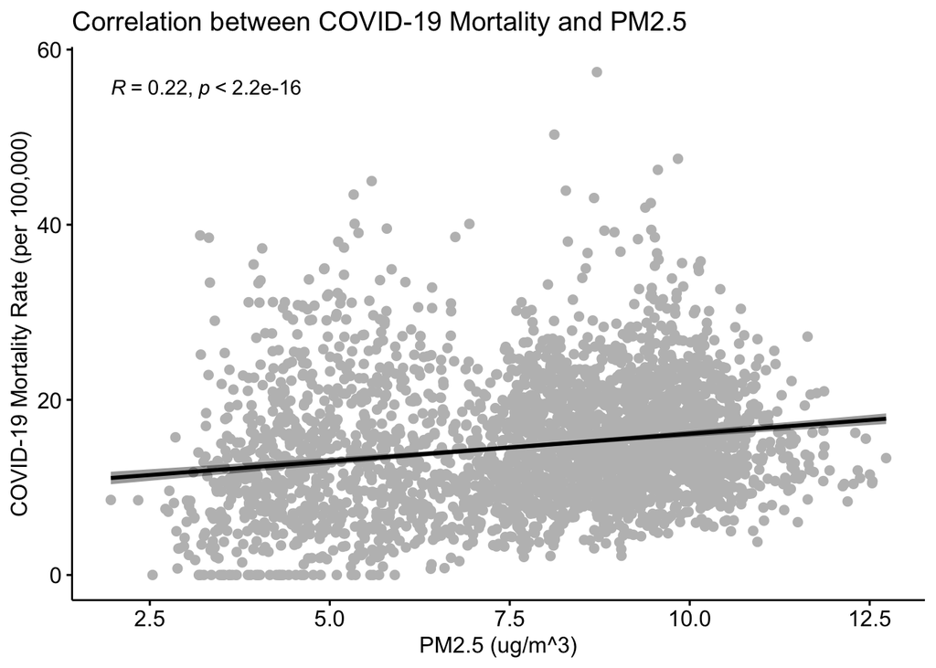

```r
library(ggplot2)
library(ggpubr)
# Correlation Plot
ggscatter(
   reg_data,
   x = "mean_pm25",
   y = "Mortality",
   add = "reg.line",
   conf.int = TRUE,
   cor.coef = TRUE,
   cor.method = "spearman",
   color = "gray",
   add.params = list(color = "black"),
   sample = 18,
   palette = "uchicago",
   xlab = "PM2.5 (ug/m^3)",
   ylab = "COVID-19 Mortality Rate (per 100,000)",
   title = "Correlation between COVID-19 Mortality and PM2.5") # R = 0.22
```

```r
ggsave("correlation_plot.tiff", units="in", width=6, height=6, dpi=200, compression = 'lzw')
```

Our Figure 1 in Part I is shown above, based on Figure 1, we can see that the correlation coefficient is 0.22 with a p-value < 0.001.

## Step 2: Linear Regression Model: predict the mean COVID mortality rate adjusted by demographics, socioeconomic status, behavior risk factors, and environmental conditions.

In this part, we are using linear models to predict mean COVID mortality rate. Our predictor of interest is *PM2.5 exposure*, which is measured as the 17-year average concentration 2000-2016 by [van Donekelaar et al](https://pubs.acs.org/doi/10.1021/acs.est.8b06392). To adjust for confounding bias in the nationwide observational study, we use county-level variables from numerous public sources: (1) [US Census/American Community Survey](https://www.census.gov/programs-surveys/acs/data.html), (2) [Robert Wood Johnson Foundation County Health Rankings](https://www.countyhealthrankings.org/), (3) [Gridmet via Google Earth engine](http://www.climatologylab.org/gridmet.html). We will also consider the potential effect of nationwide vaccination campaigns since April 15, 2021.

```r
# read in COVID dataset before Vaccination become nationwide available (before April 15, 2021)
# Calculate COVID-19 mortality rate and prepare sample dataset for analysis

df_bfVax <- read.csv("/Users/jenniferdai/Desktop/BST260-Final-Project/Data/aggregate_pm_census_cdc_210415.csv")
reg_data_bfVax <- df_bfVax %>% mutate(Mortality = Deaths/Population * 100000)
```

```r
library(emmeans)
# crude model, predictor: PM2.5 exposure
lm_fit = lm(log(1 + Mortality) ~ mean_pm25, data = reg_data)
summary(lm_fit)
```

```
##
## Call:
## lm(formula = log(1 + Mortality) ~ mean_pm25, data = reg_data)
##
## Residuals:
##      Min       1Q   Median       3Q      Max
## -2.48354 -0.26441  0.04405  0.33913  1.40651
##
## Coefficients:
##             Estimate Std. Error t value Pr(>|t|)
## (Intercept) 2.032000   0.036453   55.74   <2e-16 ***
## mean_pm25   0.076490   0.004471   17.11   <2e-16 ***
## ---
## Signif. codes:  0 '***' 0.001 '**' 0.01 '*' 0.05 '.' 0.1 ' ' 1
##
## Residual standard error: 0.5394 on 3102 degrees of freedom
##   (1 observation deleted due to missingness)
## Multiple R-squared:  0.08622,    Adjusted R-squared:  0.08593
## F-statistic: 292.7 on 1 and 3102 DF,  p-value: < 2.2e-16
```

```r
lsmeans(lm_fit,  ~ mean_pm25)
```

```
##  mean_pm25 lsmean      SE   df lower.CL upper.CL
##       7.86   2.63 0.00968 3102     2.61     2.65
##
## Results are given on the log (not the response) scale.
## Confidence level used: 0.95
```

Based on the result of crude model, we observed a positive association between COVID-19 mortality rate and long-term PM2.5 exposure. 1 ug/m^3 increase of 17-years average PM2.5 exposure is associated with 7.6% increase of COVID-19 mortality rate on the county-level.

### Full Data up until Nov. 1, 2021

```r
# Mortality Date up until Nov. 1, 2021
# Adjusted by demographics, socioeconomic status, behavior risk factors, and environmental conditions
# Scale covariates in order to make it easier to interpret regression coeffcients

lm_fit_adjusted = lm(log(1 + Mortality) ~ mean_pm25 +
                        scale(smoke) +
                        scale(obese) +
                        scale(poverty) +
                        scale(no_grad) +
                        scale(owner_occupied) +
                        scale(blk_pct) +
                        scale(hispanic_pct) +
                        scale(age_pct_65_plus) +
                        scale(age_pct_45_65) +
                        scale(age_pct_15_44) +
                        scale(log(population_density)) +
                        scale(log(median_household_income)) +
                        scale(log(median_house_value)) +
                        scale(mean_summer_temp) + scale(mean_winter_temp) + scale(mean_summer_rm) + scale(mean_winter_rm) +
                        offset(log(Population)), data = reg_data)

summary(lm_fit_adjusted)
```

```
##
## Call:
## lm(formula = log(1 + Mortality) ~ mean_pm25 + scale(smoke) +
##     scale(obese) + scale(poverty) + scale(no_grad) + scale(owner_occupied) +
##     scale(blk_pct) + scale(hispanic_pct) + scale(age_pct_65_plus) +
##     scale(age_pct_45_65) + scale(age_pct_15_44) + scale(log(population_density)) +
##     scale(log(median_household_income)) + scale(log(median_house_value)) +
##     scale(mean_summer_temp) + scale(mean_winter_temp) + scale(mean_summer_rm) +
##     scale(mean_winter_rm) + offset(log(Population)), data = reg_data)
##
## Residuals:
##     Min      1Q  Median      3Q     Max
## -2.5671 -0.4025 -0.0258  0.3568  5.3252
##
## Coefficients:
##                                      Estimate Std. Error  t value Pr(>|t|)
## (Intercept)                         -11.23233    0.09786 -114.781  < 2e-16 ***
## mean_pm25                             0.09055    0.01234    7.337 2.79e-13 ***
## scale(smoke)                          0.07948    0.02476    3.211 0.001338 **
## scale(obese)                         -0.05048    0.01674   -3.016 0.002581 **
## scale(poverty)                       -0.11485    0.03190   -3.600 0.000323 ***
## scale(no_grad)                        0.19410    0.02484    7.814 7.52e-15 ***
## scale(owner_occupied)                -0.03019    0.01944   -1.553 0.120634
## scale(blk_pct)                        0.02996    0.01902    1.575 0.115316
## scale(hispanic_pct)                  -0.06412    0.02180   -2.941 0.003295 **
## scale(age_pct_65_plus)                0.19905    0.03228    6.166 7.91e-10 ***
## scale(age_pct_45_65)                 -0.08634    0.02419   -3.570 0.000363 ***
## scale(age_pct_15_44)                 -0.03810    0.03606   -1.057 0.290785
## scale(log(population_density))       -1.29798    0.02616  -49.613  < 2e-16 ***
## scale(log(median_household_income))  -0.03062    0.03834   -0.799 0.424622
## scale(log(median_house_value))       -0.12787    0.02935   -4.357 1.36e-05 ***
## scale(mean_summer_temp)               0.20447    0.03195    6.401 1.78e-10 ***
## scale(mean_winter_temp)              -0.21564    0.03033   -7.109 1.45e-12 ***
## scale(mean_summer_rm)                 0.29525    0.02173   13.586  < 2e-16 ***
## scale(mean_winter_rm)                -0.12649    0.01770   -7.144 1.12e-12 ***
## ---
## Signif. codes:  0 '***' 0.001 '**' 0.01 '*' 0.05 '.' 0.1 ' ' 1
##
## Residual standard error: 0.7157 on 3085 degrees of freedom
##   (1 observation deleted due to missingness)
## Multiple R-squared:  0.4828, Adjusted R-squared:  0.4798
## F-statistic:   160 on 18 and 3085 DF,  p-value: < 2.2e-16
```

```r
lsmeans(lm_fit_adjusted, ~ mean_pm25)
```

```
##  mean_pm25 lsmean     SE   df lower.CL upper.CL
##       7.86   2.47 0.0283 3085     2.42     2.53
##
## Results are given on the log (not the response) scale.
## Confidence level used: 0.95
```

**Full Data up until Nov. 1, 2021**: Overall, the F-statistics is 160 with the p-value < 0.001. We can use linear model to fit our regression. After adjusting for demographics, socioeconomic status, behavior risk factors, and environmental conditions, the estimate coefficient of PM2.5 exposure is 0.09 with a p-value < 0.001, which indicates 1 ug/m^3 increase of 17-years average PM2.5 exposure is associated with 9.1% increase of COVID-19 mortality rate on the county-level. In addition, coefficients of the older age distribution, the percentage of people living in poverty, the percentage of hispanic population, and the percentage of current smoker were all significant at the 5% level, which showed that these factors were strong predictors for COVID-19 mortality rate in a relatively longer time window (from March 2020 to November 2021).

Specifically, the results showed a significant inequity situation in COVID-19 related health disparities among some vulnerable population. We found a 19.4% increase in COVID-19 mortality risk was significantly associated with a 1-SD (per 6.3%) increase in the percentage of people with less than high school education within county-level. It also suggested that a 4.4% increase in the percentage of people aged over 65 was significantly associated with a 19.9% increase in COVID-19 death risk. In addition, we did not find significant association between percentage of black population and COVID-19 mortality risk on the county-level.

### Pre-vaccination Data up until Apr. 15, 2021

```r
# Mortality Date up until Apr. 15, 2021
# Adjusted by demographics, socioeconomic status, behavior risk factors, and environmental conditions
# Scale covariates in order to make it easier to interpret regression coeffcients

lm_fit_adjusted_bfVax = lm(log(1 + Mortality) ~ mean_pm25 +
                        scale(smoke) +
                        scale(obese) +
                        scale(poverty) +
                        scale(no_grad) +
                        scale(owner_occupied) +
                        scale(blk_pct) +
                        scale(hispanic_pct) +
                        scale(age_pct_65_plus) +
                        scale(age_pct_45_65) +
                        scale(age_pct_15_44) +
                        scale(log(population_density)) +
                        scale(log(median_household_income)) +
                        scale(log(median_house_value)) +
                        scale(mean_summer_temp) + scale(mean_winter_temp) + scale(mean_summer_rm) + scale(mean_winter_rm) +
                        offset(log(Population)), data = reg_data_bfVax)

summary(lm_fit_adjusted_bfVax)
```

```
##
## Call:
## lm(formula = log(1 + Mortality) ~ mean_pm25 + scale(smoke) +
##     scale(obese) + scale(poverty) + scale(no_grad) + scale(owner_occupied) +
##     scale(blk_pct) + scale(hispanic_pct) + scale(age_pct_65_plus) +
##     scale(age_pct_45_65) + scale(age_pct_15_44) + scale(log(population_density)) +
##     scale(log(median_household_income)) + scale(log(median_house_value)) +
##     scale(mean_summer_temp) + scale(mean_winter_temp) + scale(mean_summer_rm) +
##     scale(mean_winter_rm) + offset(log(Population)), data = reg_data_bfVax)
##
## Residuals:
##     Min      1Q  Median      3Q     Max
## -2.6914 -0.4287 -0.0344  0.3833  5.4384
##
## Coefficients:
##                                      Estimate Std. Error  t value Pr(>|t|)
## (Intercept)                         -11.46335    0.09973 -114.941  < 2e-16 ***
## mean_pm25                             0.08046    0.01258    6.396 1.83e-10 ***
## scale(smoke)                          0.07652    0.02523    3.033 0.002443 **
## scale(obese)                         -0.06620    0.01706   -3.881 0.000106 ***
## scale(poverty)                       -0.10524    0.03251   -3.237 0.001221 **
## scale(no_grad)                        0.20587    0.02531    8.132 6.03e-16 ***
## scale(owner_occupied)                -0.04663    0.01982   -2.353 0.018676 *
## scale(blk_pct)                        0.06951    0.01938    3.586 0.000341 ***
## scale(hispanic_pct)                  -0.04630    0.02222   -2.084 0.037251 *
## scale(age_pct_65_plus)                0.25125    0.03290    7.637 2.95e-14 ***
## scale(age_pct_45_65)                 -0.11917    0.02465   -4.834 1.40e-06 ***
## scale(age_pct_15_44)                 -0.02815    0.03675   -0.766 0.443703
## scale(log(population_density))       -1.27165    0.02666  -47.693  < 2e-16 ***
## scale(log(median_household_income))   0.06863    0.03908    1.756 0.079146 .
## scale(log(median_house_value))       -0.17661    0.02991   -5.905 3.91e-09 ***
## scale(mean_summer_temp)               0.27695    0.03256    8.507  < 2e-16 ***
## scale(mean_winter_temp)              -0.32734    0.03092  -10.588  < 2e-16 ***
## scale(mean_summer_rm)                 0.33924    0.02215   15.317  < 2e-16 ***
## scale(mean_winter_rm)                -0.14116    0.01804   -7.823 7.02e-15 ***
## ---
## Signif. codes:  0 '***' 0.001 '**' 0.01 '*' 0.05 '.' 0.1 ' ' 1
##
## Residual standard error: 0.7294 on 3085 degrees of freedom
##   (1 observation deleted due to missingness)
## Multiple R-squared:  0.4821, Adjusted R-squared:  0.479
## F-statistic: 159.5 on 18 and 3085 DF,  p-value: < 2.2e-16
```

```r
#lsmeans(lm_fit_adjusted_bfVax, ~ mean_pm25)
```

```
#> summary(reg_data_bfVax$age_pct_65_plus)
```

```r
#   Min. 1st Qu.  Median    Mean 3rd Qu.    Max.
#0.03855 0.14829 0.17280 0.17635 0.19944 0.53106
# Std. Dev. of age_pct_65_plus = .044
#lsmeans(lm_fit_adjusted_bfVax, "mean_pm25", by = "age_pct_65_plus", at = list(age_pct_65_plus = c(0.13, 0.22)))
```

**Pre-vaccination Data up until Apr. 15, 2021**: Overall, the F-statistics is 159.5 with the p-value < 0.001. We can use linear model to fit our regression. After adjusting for demographics, socioeconomic status, behavior risk factors, and environmental conditions, the estimate coefficient of PM2.5 exposure is 0.08 with a p-value < 0.001, which indicates 1 ug/m^3 increase of 17-years average PM2.5 exposure is associated with 8% increase of COVID-19 mortality rate on the county-level. In addition, coefficients of the older age distribution, the percentage of people living in poverty, the percentage of black and hispanic population, and the percentage of current smoker were all significant at the 5% level, which showed that these factors were strong predictors for COVID-19 mortality rate before COVID-19 Vaccine become nationwide available (from March 2020 to mid-Apr 2021).

Specifically, the results also showed a significant inequity situation in COVID-19 related health disparities among some vulnerable population. We found a 20.6% increase in COVID-19 mortality risk was significantly associated with a 1-SD increase in the percentage of people with less than high school education within county-level. It also suggested that a 1-SD increase in the percentage of people aged over 65 was significantly associated with a 25.1% increase in COVID-19 death risk. In addition, we found a significant positive association between percentage of black population and COVID-19 mortality risk on the county-level.

If we compare two linear models above, we can see a decrease of estimate coefficient for `no_grad` and `age_pct_65_plus` after the launch of COVID-19 vaccination campaigns, which means that COVID-19 vaccine mitigates the effect of demographics/socioeconomic status on COVID-19 mortality risk. We also found a no significant association between percentage of black population and COVID-19 mortality risk after including more data points after vaccination. The result also suggests that COVID-19 vaccination protects vulnerable population like black people from Covid-19 deaths.

## Step 3: Logistic Regression Model: predict odds of COVID-19 mortality >= median value (compared to COVID-19 mortality rate less than median value) for Full Data and Pre-vaccination Data

Since there are extreme values in COVID-19 mortality rates of large metropolitan like NYC, LA, etc., we also dichotimized mortality into a binary variable (for example, in full data, >= 14.07 deaths per 100,000 vs. < 14.07 deaths per 100,000) and again fit the associations using logistic regression models:

```r
reg_data_log <- reg_data %>%
   mutate(Mortality_new = ifelse(Mortality >= 14.07, 1, 0))

logit_fit_adjusted = glm(Mortality_new ~ mean_pm25 +
                        scale(smoke) +
                        scale(obese) +
                        scale(poverty) +
                        scale(no_grad) +
                        scale(owner_occupied) +
                        scale(blk_pct) +
                        scale(hispanic_pct) +
                        scale(age_pct_65_plus) +
                        scale(age_pct_45_65) +
                        scale(age_pct_15_44) +
                        scale(log(population_density)) +
                        scale(log(median_household_income)) +
                        scale(log(median_house_value)) +
                        scale(mean_summer_temp) + scale(mean_winter_temp) + scale(mean_summer_rm) + scale(mean_winter_rm)
                        , data = reg_data_log, family = "binomial")

summary(logit_fit_adjusted)
```

```
##
## Call:
## glm(formula = Mortality_new ~ mean_pm25 + scale(smoke) + scale(obese) +
##     scale(poverty) + scale(no_grad) + scale(owner_occupied) +
##     scale(blk_pct) + scale(hispanic_pct) + scale(age_pct_65_plus) +
##     scale(age_pct_45_65) + scale(age_pct_15_44) + scale(log(population_density)) +
##     scale(log(median_household_income)) + scale(log(median_house_value)) +
##     scale(mean_summer_temp) + scale(mean_winter_temp) + scale(mean_summer_rm) +
##     scale(mean_winter_rm), family = "binomial", data = reg_data_log)
##
## Deviance Residuals:
##      Min        1Q    Median        3Q       Max
## -2.40437  -0.92382   0.01726   0.89586   2.43843
##
## Coefficients:
##                                     Estimate Std. Error z value Pr(>|z|)
## (Intercept)                         -0.19794    0.32468  -0.610 0.542108
## mean_pm25                            0.02074    0.04072   0.509 0.610501
## scale(smoke)                         0.08554    0.07994   1.070 0.284627
## scale(obese)                         0.03896    0.05541   0.703 0.481998
## scale(poverty)                      -0.07021    0.10608  -0.662 0.508087
## scale(no_grad)                       0.33795    0.08180   4.132 3.60e-05 ***
## scale(owner_occupied)                0.05125    0.06490   0.790 0.429655
## scale(blk_pct)                       0.10971    0.06566   1.671 0.094722 .
## scale(hispanic_pct)                  0.04411    0.07651   0.577 0.564259
## scale(age_pct_65_plus)               0.18646    0.11063   1.685 0.091898 .
## scale(age_pct_45_65)                -0.36753    0.08104  -4.535 5.75e-06 ***
## scale(age_pct_15_44)                -0.39918    0.12175  -3.279 0.001043 **
## scale(log(population_density))       0.21801    0.08899   2.450 0.014294 *
## scale(log(median_household_income)) -0.18795    0.13018  -1.444 0.148808
## scale(log(median_house_value))      -0.39722    0.09794  -4.056 5.00e-05 ***
## scale(mean_summer_temp)              0.67839    0.11661   5.818 5.97e-09 ***
## scale(mean_winter_temp)             -0.20980    0.10884  -1.928 0.053904 .
## scale(mean_summer_rm)                0.10058    0.07385   1.362 0.173221
## scale(mean_winter_rm)               -0.20588    0.05922  -3.477 0.000508 ***
## ---
## Signif. codes:  0 '***' 0.001 '**' 0.01 '*' 0.05 '.' 0.1 ' ' 1
##
## (Dispersion parameter for binomial family taken to be 1)
##
##     Null deviance: 4303.1  on 3103  degrees of freedom
## Residual deviance: 3423.7  on 3085  degrees of freedom
##   (1 observation deleted due to missingness)
## AIC: 3461.7
##
## Number of Fisher Scoring iterations: 4
```

```r
exp(coef(logit_fit_adjusted))
```

```
##                         (Intercept)                           mean_pm25
##                           0.8204227                           1.0209594
##                        scale(smoke)                        scale(obese)
##                           1.0893013                           1.0397285
##                      scale(poverty)                      scale(no_grad)
##                           0.9322027                           1.4020738
##               scale(owner_occupied)                      scale(blk_pct)
##                           1.0525901                           1.1159583
##                 scale(hispanic_pct)              scale(age_pct_65_plus)
##                           1.0450984                           1.2049718
##                scale(age_pct_45_65)                scale(age_pct_15_44)
##                           0.6924453                           0.6708688
##      scale(log(population_density)) scale(log(median_household_income))
##                           1.2435989                           0.8286600
##      scale(log(median_house_value))             scale(mean_summer_temp)
##                           0.6721881                           1.9706936
##             scale(mean_winter_temp)               scale(mean_summer_rm)
##                           0.8107464                           1.1058103
##               scale(mean_winter_rm)
##                           0.8139268
```

**Full Data up until Nov. 1, 2021**: The estimate coefficient could be interpreted as the probability of COVID-19 mortality rate >= 14.07 deaths per 100,000 associated with a 1 μg/m3 change in 17-years average PM2.5 exposure on county-level. Comparing to linear regression model, the estimate coefficient of PM2.5 exposure in logistic regression is not sigificant on the 5% level, which may suggest that linear regression model is better to fit the relationship of COVID-19 mortality risk and PM2.5 exposure in a relatively longer time window (from March 2020 to November 2021).

Similar to findings in the linear regressions results, after adjusting for confounders, coefficients of the age distribution, the percentage of people with less than high school education, the median house value were all significant at the 5% level, which showed that these factors were strong predictors for odds of higher COVID-19 mortality risk in a relatively longer time window (from March 2020 to November 2021).

```r
reg_data_log_bfVax <- reg_data_bfVax %>%
   mutate(Mortality_new = ifelse(Mortality >= 10.08, 1, 0))

logit_fit_adjusted_bfVax = glm(Mortality_new ~ mean_pm25 +
                        scale(smoke) +
                        scale(obese) +
                        scale(poverty) +
                        scale(no_grad) +
                        scale(owner_occupied) +
                        scale(blk_pct) +
                        scale(hispanic_pct) +
                        scale(age_pct_65_plus) +
                        scale(age_pct_45_65) +
                        scale(age_pct_15_44) +
                        scale(log(population_density)) +
                        scale(log(median_household_income)) +
                        scale(log(median_house_value)) +
                        scale(mean_summer_temp) + scale(mean_winter_temp) + scale(mean_summer_rm) + scale(mean_winter_rm)
                        , data = reg_data_log_bfVax, family = "binomial")

summary(logit_fit_adjusted_bfVax)
```

```
##
## Call:
## glm(formula = Mortality_new ~ mean_pm25 + scale(smoke) + scale(obese) +
##     scale(poverty) + scale(no_grad) + scale(owner_occupied) +
##     scale(blk_pct) + scale(hispanic_pct) + scale(age_pct_65_plus) +
##     scale(age_pct_45_65) + scale(age_pct_15_44) + scale(log(population_density)) +
##     scale(log(median_household_income)) + scale(log(median_house_value)) +
##     scale(mean_summer_temp) + scale(mean_winter_temp) + scale(mean_summer_rm) +
##     scale(mean_winter_rm), family = "binomial", data = reg_data_log_bfVax)
##
## Deviance Residuals:
##     Min       1Q   Median       3Q      Max
## -2.3453  -0.9990   0.1702   0.9649   2.2643
##
## Coefficients:
##                                     Estimate Std. Error z value Pr(>|z|)
## (Intercept)                         -0.23570    0.31847  -0.740 0.459226
## mean_pm25                            0.02508    0.04004   0.626 0.531098
## scale(smoke)                         0.26724    0.07867   3.397 0.000681 ***
## scale(obese)                        -0.02523    0.05393  -0.468 0.639834
## scale(poverty)                      -0.24716    0.10339  -2.391 0.016820 *
## scale(no_grad)                       0.29999    0.08025   3.738 0.000185 ***
## scale(owner_occupied)               -0.03499    0.06352  -0.551 0.581677
## scale(blk_pct)                       0.31844    0.06377   4.994 5.92e-07 ***
## scale(hispanic_pct)                  0.26750    0.07665   3.490 0.000483 ***
## scale(age_pct_65_plus)               0.44397    0.11023   4.028 5.63e-05 ***
## scale(age_pct_45_65)                -0.39444    0.08139  -4.847 1.26e-06 ***
## scale(age_pct_15_44)                -0.26862    0.11945  -2.249 0.024519 *
## scale(log(population_density))       0.25710    0.08811   2.918 0.003522 **
## scale(log(median_household_income))  0.09671    0.12666   0.764 0.445145
## scale(log(median_house_value))      -0.50131    0.09651  -5.195 2.05e-07 ***
## scale(mean_summer_temp)              0.65776    0.11545   5.698 1.22e-08 ***
## scale(mean_winter_temp)             -0.38715    0.10748  -3.602 0.000316 ***
## scale(mean_summer_rm)                0.14634    0.07490   1.954 0.050726 .
## scale(mean_winter_rm)               -0.13941    0.05848  -2.384 0.017126 *
## ---
## Signif. codes:  0 '***' 0.001 '**' 0.01 '*' 0.05 '.' 0.1 ' ' 1
##
## (Dispersion parameter for binomial family taken to be 1)
##
##     Null deviance: 4303.1  on 3103  degrees of freedom
## Residual deviance: 3561.3  on 3085  degrees of freedom
##   (1 observation deleted due to missingness)
## AIC: 3599.3
##
## Number of Fisher Scoring iterations: 4
```

```r
exp(coef(logit_fit_adjusted_bfVax))
```

```
##                         (Intercept)                           mean_pm25
##                           0.7900141                           1.0253938
##                        scale(smoke)                        scale(obese)
##                           1.3063529                           0.9750809
##                      scale(poverty)                      scale(no_grad)
##                           0.7810146                           1.3498492
##               scale(owner_occupied)                      scale(blk_pct)
##                           0.9656103                           1.3749832
##                 scale(hispanic_pct)              scale(age_pct_65_plus)
##                           1.3066958                           1.5588846
##                scale(age_pct_45_65)                scale(age_pct_15_44)
##                           0.6740550                           0.7644339
##      scale(log(population_density)) scale(log(median_household_income))
##                           1.2931736                           1.1015360
##      scale(log(median_house_value))             scale(mean_summer_temp)
##                           0.6057338                           1.9304650
##             scale(mean_winter_temp)               scale(mean_summer_rm)
##                           0.6789909                           1.1575878
##               scale(mean_winter_rm)
##                           0.8698691
```

**Pre-vaccination Data up until Apr. 15, 2021**: Similar to full dataset, the estimate coefficient could be interpreted as the probability of COVID-19 mortality rate >= 10.08 deaths per 100,000 associated with a 1 μg/m3 change in 17-years average PM2.5 exposure on county-level. Comparing to linear regression model, the estimate coefficient of PM2.5 exposure in logistic regression is not sigificant on the 5% level, which may suggest that linear regression model is better to fit the relationship of COVID-19 mortality risk and PM2.5 exposure before COVID-19 Vaccine become nationwide available (from March 2020 to mid-Apr 2021).

In addition, coefficients of the age distribution, the percentage of people with less than high school education, the percentage of black and hispanic population, and the percentage of current smoker were all significant at the 5% level, which showed that these factors were strong predictors for odds of higher COVID-19 mortality risk before COVID-19 Vaccine become nationwide available (from March 2020 to mid-Apr 2021).

If we compare two linear models above, the results also showed a mitigation effect of vaccination on COVID-19 death regarding various health disparities among vulnerable population. We found no significant coefficient estimates for `poverty`, `smoke`, `blk_pct`, `hispanic_pct` and `age_pct_65_plus` after including more data points after vaccination. The result suggested that COVID-19 vaccine mitigated the effect of demographics/socioeconomic status on COVID-19 mortality risk across county-level. In other words, COVID-19 vaccinations protect vulnerable population like black people, people aged over 65, and people living in poverty from Covid-19 deaths.